# Section 3.7 – Travaux Pratiques : Simulation et Bootstrap

## 1.3 3.7.2 Simulation de Variables Aléatoires

### 1.3.1 Contexte

R dispose de nombreuses fonctions pour générer des variables aléatoires : `rnorm()`, `rbinom()`, `runif()`, etc.

**Mais que faire si la loi n’existe pas dans R ?**

Nous présentons deux **méthodes classiques** :

1. **Transformation inverse** : utiliser l’inverse de la fonction de répartition
2. **Simulation discrète** : diviser l’intervalle [0,1] en sous-intervalles

### 1.3.2 Méthode 1 : Transformation Inverse pour Loi Exponentielle

**Théorie :** Si est la fonction de répartition, et , alors :

**Pour la loi exponentielle :**

**Inverse :**

**Avantage :** Méthode simple et efficace !

On sait que si alors sa fonction de répartition est

L’inverse de cette fonction est :

On peut donc simuler observations de en utilisant des réalisations issues d’une loi uniforme sur .

```r
# ========= Transformation Inverse: Loi Exponentielle =========

cat("\n=== Simulation de Exp(λ=2) par Transformation Inverse ===\n\n")
```

```
=== Simulation de Exp(λ=2) par Transformation Inverse ===
```

```r
# Paramètres
n <- 10000
lambda <- 2

# Étape 1: Générer U ~ Uniform(0,1)
U <- runif(n)

# Étape 2: Appliquer la formule inverse
X_exp <- -log(1 - U) / lambda

cat("Données simulées: n =", n, "observations d'Exp(2)\n\n")
```

```
Données simulées: n = 10000 observations d'Exp(2)
```

```r
cat("Vérification statistique:\n")
```

```
Vérification statistique:
```

```r
cat("  Moyenne observée:   ", round(mean(X_exp), 4), "\n")
```

```
  Moyenne observée:    0.4986
```

```r
cat("  Moyenne théorique:  ", 1/lambda, "(car E[Exp(λ)]=1/λ)\n")
```

```
  Moyenne théorique:   0.5 (car E[Exp(λ)]=1/λ)
```

```r
cat("  Variance observée:  ", round(var(X_exp), 4), "\n")
```

```
  Variance observée:   0.2468
```

```r
cat("  Variance théorique: ", 1/lambda^2, "(car Var[Exp(λ)]=1/λ²)\n\n")
```

```
  Variance théorique:  0.25 (car Var[Exp(λ)]=1/λ²)
```

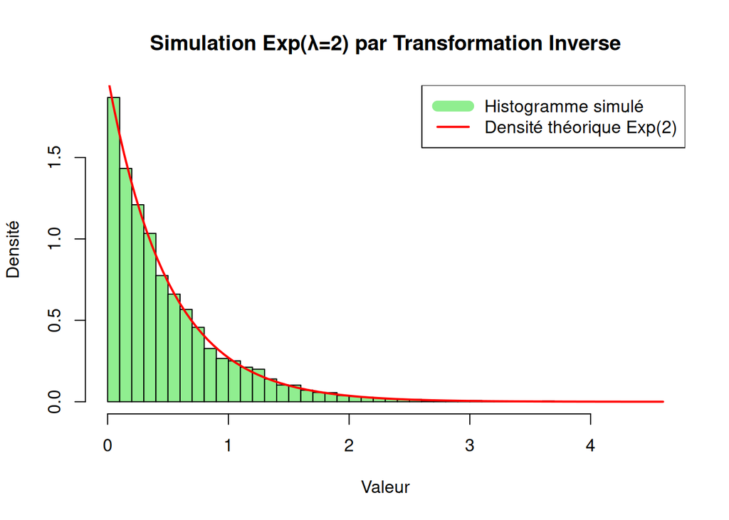

```r
# Visualisation
hist(X_exp, breaks = 40, freq = FALSE, col = "lightgreen",
     main = "Simulation Exp(λ=2) par Transformation Inverse",
     xlab = "Valeur",
     ylab = "Densité")

# Superposer la densité théorique
curve(dexp(x, rate = lambda), add = TRUE, col = "red", lwd = 2)

legend("topright",
       legend = c("Histogramme simulé", "Densité théorique Exp(2)"),
       col = c("lightgreen", "red"),
       lty = c(1, 1),
       lwd = c(10, 2))
```

```r
cat("Les deux courbes se superposent: la simulation est valide !\n")
```

```
Les deux courbes se superposent: la simulation est valide !
```

Les deux courbes se superposent, confirmant que la simulation correspond bien à une loi exponentielle de paramètre 2.

### 1.3.3 Méthode 2 : Simulation Discrète Uniforme

**Objectif :** Simuler une variable aléatoire **discrète** uniforme sur .

**Principe :**

- Diviser l’intervalle en 6 sous-intervalles égaux :
- Si , alors
- Mathématiquement : où est la partie entière

**Avantage :** Fonctionne pour n’importe quelle distribution discrète !

```r
# ========= Simulation Discrète: Uniforme sur {0,1,2,3,4,5} =========

cat("\n=== Simulation Discrète Uniforme ===\n\n")
```

```
=== Simulation Discrète Uniforme ===
```

```r
# Paramètres
n <- 10000

# Étape 1: Générer U ~ Uniform(0,1)
U <- runif(n)

# Étape 2: Transformer en variable discrète
# La formule floor(U * 6) produit un entier dans {0,1,2,3,4,5}
X_discrete <- floor(U * 6)

cat("Nombre d'observations: n =", n, "\n\n")
```

```
Nombre d'observations: n = 10000
```

```r
# Compter les fréquences
freq <- table(X_discrete)
cat("Fréquences observées:\n")
```

```
Fréquences observées:
```

```r
print(freq)
```

```
X_discrete
   0    1    2    3    4    5
1663 1649 1658 1720 1676 1634
```

```r
cat("\nFréquences théoriques (1/6 chacun ≈", round(n/6, 0), ")\n\n")
```

```
Fréquences théoriques (1/6 chacun ≈ 1667 )
```

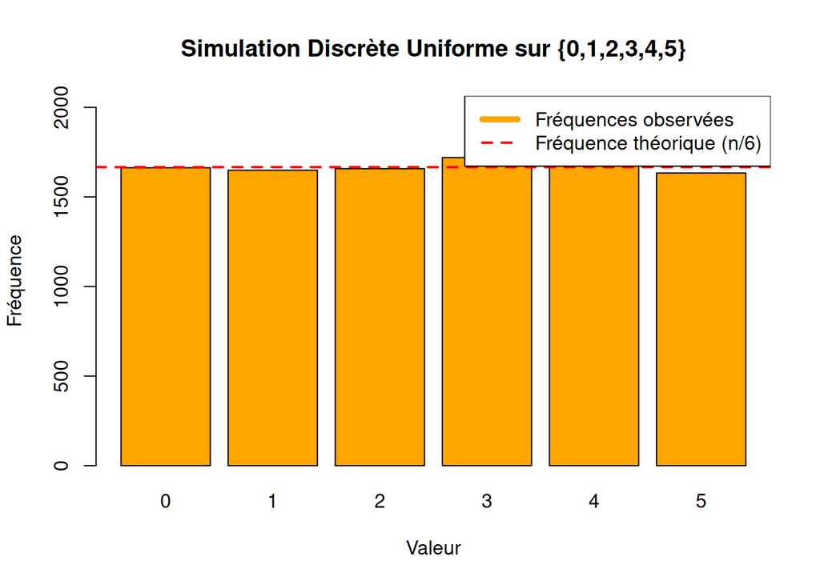

```r
# Visualisation
barplot(freq, col = "orange",
        main = "Simulation Discrète Uniforme sur {0,1,2,3,4,5}",
        xlab = "Valeur",
        ylab = "Fréquence",
        ylim = c(0, max(freq) * 1.2))

# Ajouter une ligne référence pour l'équilibre
abline(h = n/6, col = "red", lwd = 2, lty = 2)

legend("topright",
       legend = c("Fréquences observées", "Fréquence théorique (n/6)"),
       col = c("orange", "red"),
       lty = c(1, 2),
       lwd = c(5, 2))
```

```r
cat("Interprétation: Les barres sont de hauteur égale (légères variations normales)\n")
```

```
Interprétation: Les barres sont de hauteur égale (légères variations normales)
```

```r
cat("Ceci confirme que chaque valeur a probabilité 1/6\n")
```

```
Ceci confirme que chaque valeur a probabilité 1/6
```

## 1.4 📌 Résumé et Points Clés

### 1.4.1 Ce que nous avons appris

1. **Bootstrap :**
- Méthode puissante pour estimer biais et variance à partir d’**un seul échantillon**
- Rééchantillonnage avec remise pour générer des pseudo-réplications
- Utile quand les formules théoriques ne sont pas disponibles
2. **Transformation Inverse :**
- Utiliser l’inverse de la fonction de répartition
- Exemple : où
- Efficace et simple à implémenter
3. **Simulation Discrète :**
- Diviser [0,1] en sous-intervalles selon les probabilités
- Appliquer une fonction comme
- Généralise à n’importe quelle distribution discrète

### 1.4.2 Conseils Pratiques

- ✅ Toujours **vérifier la simulation** visuellement (histogramme) et numériquement (statistiques)
- ✅ Utiliser `set.seed()` pour **reproduire les résultats**
- ✅ Adapter le nombre de réplications ( ou ) selon la **précision souhaitée**
- ✅ Le bootstrap est **non-paramétrique** : ne suppose rien sur la loi sous-jacente